# Introduction to vtree

## Pattern trees and pattern tables

*This section shows how to display all the combinations of values in a set of variables.*

Each node in a variable tree provides the frequency of a particular combination of values of the variables. The leaf nodes represent the observed combinations of values of *all* of the variables. For example, in a variable tree for `Severity` and `Sex`, the leaf nodes correspond to Mild F, Mild M, Moderate F, Moderate M, etc. These combinations, or “patterns”, can be treated as an additional variable. And if this new pattern variable is used as the first variable in a tree, then the branches of the tree will be simplified: each branch will represent a unique pattern, with no sub-branches. A “pattern tree” can be easily produced by specifying `pattern=TRUE`. For example:

```r
vtree(FakeData,"Severity Sex")
vtree(FakeData,"Severity Sex",pattern=TRUE)
```

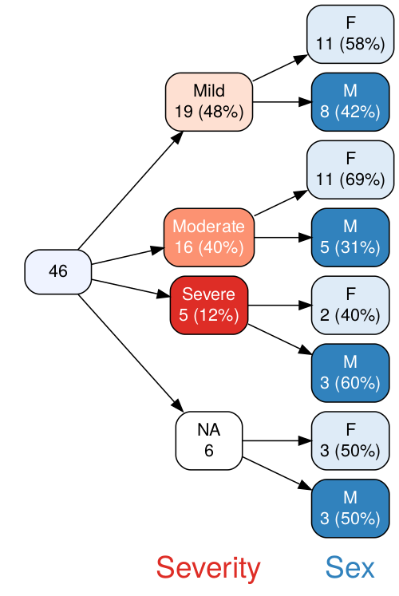

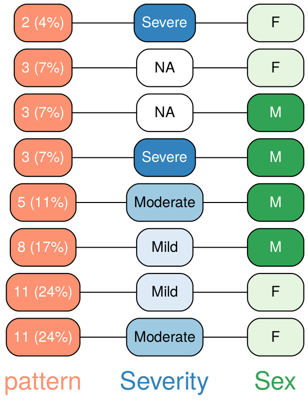

Pattern trees are simpler to read than ordinary variable trees, but they involve a considerable loss of information, since they only represent the *n*th-degree subsets (where *n* is the number of variables).

Note that by default, when `pattern=TRUE` is specified, the root node is not shown (in order to simplify the display). A disadvantage of this is that the total sample size is not shown. You can override this behavior by specifying `showroot=TRUE`.

A pattern tree has two other special characteristics. First, note that after the first layer (representing `pattern`), counts and percentages are not shown, since they are not informative: by definition, all nodes within a branch have the same count. Second, note that in place of arrows, undirected line segments are shown. This is because, unlike in a regular variable tree, the order of variables is irrelevant in a pattern tree. Sometimes, however, the variables do have a natural ordering, as in the case of longitudinal variables. To show arrows, specify `seq=TRUE` instead of `pattern=TRUE`, and a “sequence” (i.e. an ordered pattern) will be shown.

Summaries can be shown in pattern trees (using the `summary` parameter), but they only appear in the pattern node (or the sequence node if `seq=TRUE`).

### Pattern tables

A pattern tree has the same structure as a table. Indeed, it may be more convenient to produce a table rather than a pattern tree. A data frame containing the information from the pattern tree can be exported by specifying `ptable=TRUE`:

```r
vtree(FakeData,"Severity Sex",ptable=TRUE)
```

```
##    n pct Severity Sex
## 1  2   4   Severe   F
## 2  3   7     <NA>   F
## 3  3   7     <NA>   M
## 4  3   7   Severe   M
## 5  5  11 Moderate   M
## 6  8  17     Mild   M
## 7 11  24     Mild   F
## 8 11  24 Moderate   F
```

The pattern table includes a column for the counts from the pattern nodes, and a column for percentages. Compared to a variable tree, this table is much more compact, and may be more suitable for use in a manuscript.

### Indicator variables

Pattern trees can be very useful for *indicator variables*, i.e. variables that take values like 0/1, no/yes, FALSE/TRUE, etc. For convenience in this section, we’ll refer to 0 (or no, FALSE, etc.) as a *negative* and 1 (or yes, TRUE, etc.) as an *affirmative*.

The variables `Ind1` through `Ind4` in `FakeData` are 0/1 indicator variables. If these variables are interpreted as representing set membership (0 = non-member, 1 = member), then a pattern tree is an alternative representation of a Venn diagram. If you specify `Venn=TRUE`, the nodes (except for the pattern nodes) will be blank, with only their shade indicating their value (dark = 1, light = 0, white = missing).

```r
vtree(FakeData,"Ind1 Ind2 Ind3 Ind4",Venn=TRUE,pattern=TRUE)
```

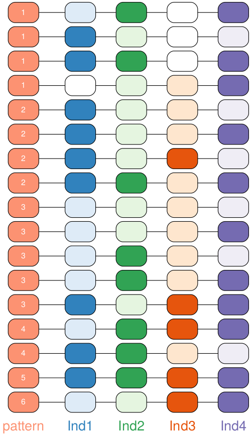

Big pattern trees can be overwhelming, so it may be useful to prune patterns that occur fewer than, say, 3 times, by specifying `prunesmaller=3`.

A pattern tree for indicator variables provides all the information that a Venn diagram represents, but unlike a Venn diagram, missing values are also represented. This can also be shown as a pattern table. For example:

```r
vtree(FakeData,"Ind1 Ind2",ptable=TRUE)
```

```
##    n pct Ind1 Ind2
## 1  1   2 <NA>    0
## 2 10  22    1    0
## 3 11  24    0    1
## 4 12  26    0    0
## 5 12  26    1    1
```

#### The `VennTable` function

For indicator variables, there is an extra function, `VennTable`, which converts the pattern table to a matrix of character strings and adds some additional totals.

```r
VennTable(vtree(FakeData,"Ind1 Ind2",ptable=TRUE))
```

```
##       n    pct   Ind2 Ind1
##       "1"  "2"   "0"  NA
##       "10" "22"  "0"  "10"
##       "11" "24"  "11" "0"
##       "12" "26"  "0"  "0"
##       "12" "26"  "12" "12"
## Total "46" "100" ""   ""
## N     ""   ""    "23" "22"
## pct   ""   ""    "50" "48"
```

By default in R, when a matrix of character strings is printed, quotation marks are displayed around each element. Unfortunately the result is unattractive. Instead it’s helpful to call the `print` function and specify `quote=FALSE`:

```r
print(VennTable(vtree(FakeData,"Ind1 Ind2",ptable=TRUE)),quote=FALSE)
```

```
##       n  pct Ind2 Ind1
##       1  2   0    <NA>
##       10 22  0    10
##       11 24  11   0
##       12 26  0    0
##       12 26  12   12
## Total 46 100
## N            23   22
## pct          50   48
```

Without all those quotation marks, it’s easier to see what `VennTable` adds:

- the total sample size (46) and percentage (100), and
- the total number (N) of affirmatives for each variable, together with a percentage.

The `VennTable` function can also be used in an R Markdown document. Specifying `markdown=TRUE` generates a pandoc markdown pipetable, with several formatting tweaks:

- the rows and columns of the table are transposed
- affirmatives are represented by checkmarks
- negatives are represented by spaces
- missing values are represented by dashes (which can be changed with the `NAcode` parameter).

To display the table in R Markdown, use this inline call:

```r
`r VennTable(vtree(FakeData,"Ind1 Ind2",ptable=TRUE),markdown=TRUE)`
```

|  |  |  |  |  |  | Total | N | % |
| --- | --- | --- | --- | --- | --- | --- | --- | --- |
| n | 1 | 10 | 11 | 12 | 12 | 46 |  |  |
| % | 2 | 22 | 24 | 26 | 26 | 100 |  |  |
| Ind2 |  |  | ✔ |  | ✔ |  | 23 | 50 |
| Ind1 | - | ✔ |  |  | ✔ |  | 22 | 48 |

`VennTable` has some additional parameters. The `checked` parameter is used to specify values that should be interpreted as affirmative. By default, it is set to `c("1","TRUE","Yes","yes","N/A")`. Similarly, the `unchecked` parameter is used to specify values that should be interpreted as negative, with default `c("0","FALSE","No","no","not N/A")`.

#### Using the `summary` parameter in pattern tables

The `summary` parameter can also be used in pattern tables. If a single summary is requested, it appears in the `summary_1` variable in the data frame. Additional summaries appear as `summary_2`, `summary_3`, etc.

```r
vtree(FakeData,"Severity Sex",summary=c("Score %mean%","Pre %mean%"),ptable=TRUE)
```

```
##    n pct Severity Sex summary_1 summary_2
## 1  2   4   Severe   F      28.0      -0.4
## 2  3   7     <NA>   F       6.3      -0.1
## 3  3   7     <NA>   M      23.7      -0.9
## 4  3   7   Severe   M      44.0      -0.3
## 5  5  11 Moderate   M       8.2 -0.7 mv=1
## 6  8  17     Mild   M  6.3 mv=1       0.2
## 7 11  24     Mild   F      15.7 -0.4 mv=2
## 8 11  24 Moderate   F 21.5 mv=1       0.0
```

### Checking for missing values with the `check.is.na` parameter

If `check.is.na=TRUE` is specified, each variable is replaced by an indicator of whether or not it is missing, and `pattern=TRUE` is automatically set. As when `Venn=TRUE` is specified, all nodes except for the pattern node are blank, and only their shade indicates missing (dark) or not (light). Whereas the variables used to build a variable tree are normally categorical, in this situation non-categorical variables can be used, because their missingness is represented instead of their actual values.

```r
vtree(FakeData,"Severity Age Pre Post",check.is.na=TRUE)
```

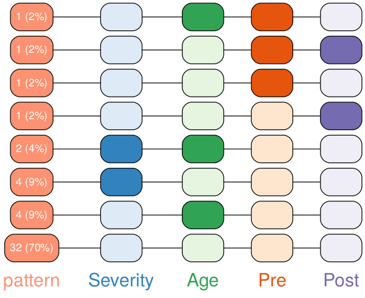

Specifying `ptable=TRUE` produces this information in a data frame, and calling `VennTable` shows additional information. To display the table in R Markdown, use this inline call:

```r
`r VennTable(vtree(FakeData,"Severity Age Pre Post",check.is.na=TRUE,ptable=TRUE),
   markdown=TRUE)`
```

|  |  |  |  |  |  |  |  |  | Total | N | % |
| --- | --- | --- | --- | --- | --- | --- | --- | --- | --- | --- | --- |
| n | 1 | 1 | 1 | 1 | 2 | 4 | 4 | 32 | 46 |  |  |
| % | 2 | 2 | 2 | 2 | 4 | 9 | 9 | 70 | 100 |  |  |
| MISSING_Age | ✔ |  |  |  | ✔ |  | ✔ |  |  | 7 | 15 |
| MISSING_Severity |  |  |  |  | ✔ | ✔ |  |  |  | 6 | 13 |
| MISSING_Pre | ✔ | ✔ | ✔ |  |  |  |  |  |  | 3 | 7 |
| MISSING_Post |  | ✔ |  | ✔ |  |  |  |  |  | 2 | 4 |

The rows `n` and `pct` represent the frequency and percentage of the total number of cases for each pattern of missingness, and the columns `N` and `pct` on the right-hand side represent the frequency and percentage of missingness for each variable.

It may be useful to identify the ID numbers for these patterns. Here the results are truncated to 15 characters:

```r
vtree(FakeData,"Severity Age Pre Post",check.is.na=TRUE,summary="id %list%%trunc=15%",
  ptable=TRUE)
```

```
##    n pct MISSING_Severity MISSING_Age MISSING_Pre MISSING_Post          summary_1
## 1  1   2          not N/A         N/A         N/A      not N/A                124
## 2  1   2          not N/A     not N/A         N/A          N/A                118
## 3  1   2          not N/A     not N/A         N/A      not N/A                108
## 4  1   2          not N/A     not N/A     not N/A          N/A                104
## 5  2   4              N/A         N/A     not N/A      not N/A           112, 135
## 6  4   9              N/A     not N/A     not N/A      not N/A 103, 116, 126, ...
## 7  4   9          not N/A         N/A     not N/A      not N/A 105, 119, 128, ...
## 8 32  70          not N/A     not N/A     not N/A      not N/A 101, 102, 106, ...
```

## Colors

*This section explains how colors and color palettes can be used.*

By default, `vtree` assigns colors to nodes of each successive variable using color palettes from RColorBrewer.

The sequence of palettes (identified by short names) is as follows:

| 1 | Reds |  | 6 | YlGn |  | 11 | BuPu |  | 16 | RdPu |
| --- | --- | --- | --- | --- | --- | --- | --- | --- | --- | --- |
| 2 | Blues |  | 7 | PuBu |  | 12 | YlOrRd |  | 17 | BuGn |
| 3 | Greens |  | 8 | PuRd |  | 13 | RdYlGn |  | 18 | OrRd |
| 4 | Oranges |  | 9 | YlOrBr |  | 14 | GnBu |  |  |  |
| 5 | Purples |  | 10 | PuBuGn |  | 15 | YlGnBu |  |  |  |

If you prefer to change the color assignments, you can use the `palette` parameter. For example, by default a variable tree for `Sex` and `Severity` will assign shades of red to nodes of `Sex` and shades of blue to notes of `Severity`. To switch to shades of, say, green and orange instead, use:

```r
vtree(FakeData,"Sex Severity",palette=c(3,4))
```

Sometimes it may be useful to reverse the order of a gradient. To reverse the order of all gradients, specify `revgradient=TRUE`. The gradient for selected variables can be reversed as in the example below:

```r
vtree(FakeData,"Sex Group Severity",revgradient=c(Sex=TRUE,Severity=TRUE))
```

Other color-related parameters include:

| `sortfill` | Specifying `sortfill=TRUE` fills nodes with gradient colors in sorted order according to the node count. |
| --- | --- |
| `NAfillcolor` | By default, missing value nodes are colored white. For a different color (say gray), specify `NAfillcolor="gray"`. To instead use a color from the current palette, specify `NAfillcolor=NULL`. |
| `rootfillcolor` | The color of the root node can be changed (say to yellow) by specifying `rootfillcolor="yellow"`. |
| `fillcolor` | To set all nodes of the tree (except for missing value nodes and the root node) to be the same color (say palegreen), specify `fillcolor="palegreen"`. |
| `plain` | A simple color scheme is produced by specifying `plain=TRUE`. (Additionally, this increases the spaces between nodes.) |

## REDCap checkboxes

*This section details support for checkbox variables from REDCap.*

In datasets exported from [REDCap](https://www.project-redcap.org/), checkboxes (i.e. select-all-that-apply boxes) are represented in a special way. For each item in a checklist, a separate variable is created. Suppose survey respondents were asked to select which flavors of ice cream (Chocolate, Vanilla, Strawberry) they like. Within REDCap, the variable name for this list of checkboxes is `IceCream`, but when the dataset is exported, individual variables `IceCream___1` (representing Chocolate), `IceCream___2` (Vanilla), and `IceCream___3` (Strawberry) are created. When the dataset is read into R, the names of the flavors are embedded in the `attributes` of these variables.

```r
dessert <- build.data.frame(
  c(   "group","IceCream___1","IceCream___2","IceCream___3"),
  list("A",     1,             0,             0,              7),
  list("A",     1,             0,             1,              2),
  list("A",     0,             0,             0,              1),
  list("A",     1,             1,             1,              1),
  list("B",     1,             0,             1,              1),
  list("B",     1,             0,             0,              2),
  list("B",     0,             1,             1,              1),
  list("B",     0,             0,             0,              1))
attr(dessert$IceCream___1,"label") <- "Ice cream (choice=Chocolate)"
attr(dessert$IceCream___2,"label") <- "Ice cream (choice=Vanilla)"
attr(dessert$IceCream___3,"label") <- "Ice cream (choice=Strawberry)"
```

### prefix `r:`

The prefix `r:` identifies a REDCap checklist variable, and extracts a label from the variable attribute. For example, the following call automatically displays “Chocolate”:

```r
vtree(dessert,"r:IceCream___1")
```

### suffix `@`

The suffix `@` matches REDCap checklist variables based on the naming scheme used by REDCap for checklist variables. For example, the following call automatically displays Chocolate, Vanilla, and Strawberry:

```r
vtree(dessert,"r:IceCream@")
```

### variable prefixes `rany:`, `rnone:`, `rall:`, and `rnotall:`

The variable prefixes `any:`, `none:`, `all:`, and `notall:` can be combined with the `r:` prefix to form `rany:`, `rnone:`, `rall:`, and `rnotall:`. For example, to determine whether anyone did not like *any* of the flavors (Chocolate, Vanilla, or Strawberry):

```r
vtree(dessert,"rnone:IceCream@")
```

### variable prefix `ri:`

“Intersections” of REDCap variables may be obtained by combining the `r:` prefix with the `i:` prefix:

```r
vtree(dessert,"ri:IceCream@")
```

### Deprecated: variable prefixes `stem:` and `rc:`

To examine the pattern of ice-cream flavor choices, the following can be used:

```r
vtree(dessert,"IceCream___1 IceCream___2 IceCream___3",pattern=TRUE)
```

One problem is that this doesn’t assign the appropriate labels to `IceCream___1` (Chocolate), `IceCream___2` (Vanilla), and `IceCream___3` (Strawberry).

Instead, try the following more compact call, which also assigns labels automatically.

```r
vtree(dessert,"stem:IceCream",pattern=TRUE)
```

The `summary` parameter also supports a `stem:` prefix:

```r
vtree(dessert,summary="stem:IceCream",splitwidth=Inf,just="l")
```

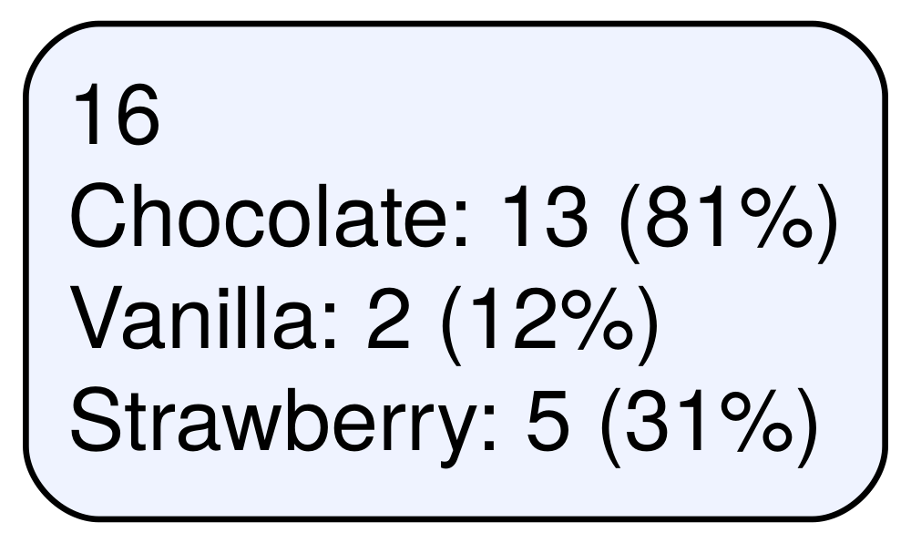

If you wish to only examine specific REDCap checkbox items, the `rc:` prefix can be used. For example to examine results for just Chocolate and Strawberry:

```r
vtree(dessert,"rc:IceCream___1 rc:IceCream___3",pattern=TRUE)
```

## The DOT script generated by `vtree`

*This section shows how to obtain the DOT script that displays a variable tree.*

Specifying `getscript=TRUE` lets you capture the DOT script representing a variable tree. (DOT is a graph description language used by Graphviz, which is used by DiagrammeR, which is used by vtree!). Here is an example:

```r
dotscript <- vtree(FakeData,"Severity",getscript=TRUE)
cat(dotscript)
```

```
digraph vtree {
graph [nodesep=0.1, ranksep=0.5, tooltip=" "]
node [fontname = "Arial", fontcolor = black,shape = rectangle, color = black, tooltip=" ",margin=0.1]
rankdir=LR;
Node_L0_0 [style=invisible]

Node_L1_0[label=<<FONT POINT-SIZE="24"><FONT COLOR="#DE2D26">Severity</FONT></FONT>> shape=none margin=0]
Node_L0_0 -> Node_L1_0 [style=invisible arrowhead=none]

edge[style=solid]
Node_1->Node_2 Node_1->Node_3 Node_1->Node_4 Node_1->Node_5

Node_1[label=<46>  fontcolor=<#000000> color=black style="rounded,filled" fillcolor=<#EFF3FF>]
Node_2[label=<Mild<BR/>19 (48%)>  fontcolor=<#000000> color=black style="rounded,filled" fillcolor=<#FEE0D2>  ]
Node_1[label=<46>  fontcolor=<#000000> color=black style="rounded,filled" fillcolor=<#EFF3FF>]
Node_3[label=<Moderate<BR/>16 (40%)>  fontcolor=<#ffffff> color=black style="rounded,filled" fillcolor=<#FC9272>  ]
Node_1[label=<46>  fontcolor=<#000000> color=black style="rounded,filled" fillcolor=<#EFF3FF>]
Node_4[label=<Severe<BR/>5 (12%)>  fontcolor=<#ffffff> color=black style="rounded,filled" fillcolor=<#DE2D26>  ]
Node_1[label=<46>  fontcolor=<#000000> color=black style="rounded,filled" fillcolor=<#EFF3FF>]
Node_5[label=<NA<BR/>6>  fontcolor=<#000000> color=black style="rounded,filled" fillcolor=<white>  ]

}
```

If you wish to directly edit this code, it can can be pasted into an online Graphviz editor, for example:

https://dreampuf.github.io/GraphvizOnline/

http://magjac.com/graphviz-visual-editor/

## Extracting a list of information about a variable tree

*This section explains how to obtain all of the counts and percentages of a variable tree.*

Sometimes it is useful to extract counts, percentages, and summary information from a variable tree. The object returned by `vtree` has an attribute `info` containing structured information about the counts and percentages in each node. Here is an example:

```r
v <- vtree(FakeData,"Group Viral",horiz=FALSE)
v
```

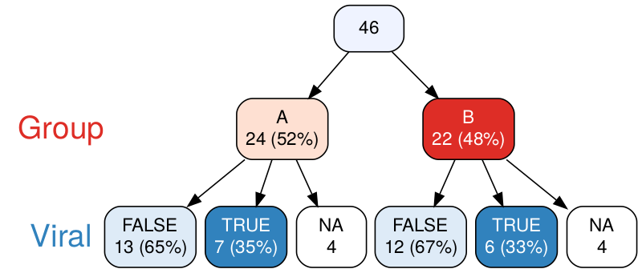

```r
attributes(v)$info
```

```
## $.n
## [1] 46
##
## $.pct
## [1] 100
##
## $Group
## $Group$A
## $Group$A$.n
## [1] 24
##
## $Group$A$.pct
## [1] 52
##
## $Group$A$Viral
## $Group$A$Viral$`FALSE`
## $Group$A$Viral$`FALSE`$.n
## [1] 13
##
## $Group$A$Viral$`FALSE`$.pct
## [1] 65
##
##
## $Group$A$Viral$`TRUE`
## $Group$A$Viral$`TRUE`$.n
## [1] 7
##
## $Group$A$Viral$`TRUE`$.pct
## [1] 35
##
##
## $Group$A$Viral$`NA`
## $Group$A$Viral$`NA`$.n
## [1] 4
##
## $Group$A$Viral$`NA`$.pct
## [1] NA
##
##
##
```

[output cut: 16 more lines]

```
##
## $Group$B$Viral$`TRUE`
## $Group$B$Viral$`TRUE`$.n
## [1] 6
##
## $Group$B$Viral$`TRUE`$.pct
## [1] 33
##
##
## $Group$B$Viral$`NA`
## $Group$B$Viral$`NA`$.n
## [1] 4
##
## $Group$B$Viral$`NA`$.pct
## [1] NA
```

The list contains the counts (`.n`), percentages (`.pct`), and summary text (`.text`) that appear in the tree.

# Ways to call vtree

`vtree` behaves differently depending on the context in which it is called.

## Calling vtree interactively

- If `vtree` is called interactively in RStudio, it displays the variable tree in the Viewer window.
- If `vtree` is called interactively from the RGui console (i.e. from R outside of RStudio), it displays the variable tree in a browser window.

## Calling vtree from knitr and R Markdown

When `vtree` is called from knitr, it generates

- A PNG file if the output format is Markdown
- A PDF file if the output format is LaTeX.

Here’s how it does that. `vtree` uses the `DiagrammeR` package, which automatically generates an `htmlwidget` object for display in HTML, using the [htmlwidgets](https://www.htmlwidgets.org/) framework. Then `vtree` converts the `htmlwidget` object into an SVG image, and finally into a PNG or PDF file.

### Generating PNG files

PNG files are useful because they allow you to display variable trees in Microsoft Word documents, and also because HTML files that use htmlwidgets can get large, and if they contain several widgets they can be slow to load.

If `vtree` is called while an R Markdown file is being knitted, it generates a PNG file and automatically embeds it into the knitted document. The resolution of the PNG file in pixels is determined by parameters `pxwidth` and `pxheight`. If neither is specified, `pxwidth` is automatically set to 2000, which provides good resolution for a printed page. The height of the image in the R Markdown output document can be specified using the `imageheight` parameter, for example `imageheight="4in"` for a 4-inch image. There is also an `imagewidth` parameter. If neither is specified, `imageheight` is automatically set to 3 inches.

*Note*: You may notice a warning in the R Markdown rendering (in RStudio, the R Markdown pane) like this:

```r
<unknown>:1919791: Invalid asm.js: Function definition doesn't match use
```

Although distracting, this message is irrelevant.

### Embedding image files

The PNG or PDF file is stored in the folder specified by the `folder` parameter, or if not specified, a temporary folder will be used. Successive PNG files are named `vtree001.png`, `vtree002.png`, and so forth and are stored in the folder. (Similarly PDF files are named `vtree001.pdf`, etc.) During knitting, `vtree` uses the `options` function in base R to store a variable called `vtcount` to count the PNG files, and a variable called `vtfolder` to identify the folder where they will be stored.

To call `vtree` in R Markdown, you can use inline code:

```r
`r vtree(FakeData,"Sex Severity")`
```

Or you can use a code chunk:

````
```{r}
vtree(FakeData,"Sex Severity")
```
````

One advantage of code chunks is that they can also be run interactively (for example within RStudio, by clicking on the green arrow at the top right of a code chunk).

### Generating an image file but not displaying it

Specifying `imageFileOnly=TRUE` instructs vtree to generate an image file but not display it.

### Generating an htmlwidget in an HTML document

When knitting to an HTML document, htmlwidgets can be used rather than embedding a PNG file. To use htmlwidgets instead of a PNG file simply specify `pngknit=FALSE`.

## `svtree`: Using vtree in Shiny

Thanks to Shiny and the svg-pan-zoom JavaScript library, interactive panning and zooming of a variable tree is possible with the `svtree` function. The syntax of `svtree` is the same as that of `vtree`, but instead of generating a static variable tree, it launches a Shiny app. The mousewheel allows you to zoom in or out. The variable tree can also be dragged to a different position.

Thanks to the panning and zooming functionality in `svtree`, it is possible to examine larger variable trees than with `vtree`. In large variable trees it is often useful to show the variable name in each node, since the variable labels (which are shown at the bottom or left-hand margin) may not be visible after zooming. To show the variable name in each node, specify `showvarinnode=TRUE`.

# Generating a data frame by specifying subset sizes

`vtree` is designed to generate a variable tree based on a data frame. However, sometimes the sizes of subsets are known but no data frame is available.

The `build.data.frame` function allows you to build a data frame by specifying the size of subsets. Here’s an example involving pets:

```r
build.data.frame(
  c("pet","breed","size"),
  list("dog","golden retriever","large",5),
  list("cat","tabby","small",2))
```

```
##   pet            breed  size
## 1 dog golden retriever large
## 2 dog golden retriever large
## 3 dog golden retriever large
## 4 dog golden retriever large
## 5 dog golden retriever large
## 6 cat            tabby small
## 7 cat            tabby small
```

In this case there are five large golden retrievers and 2 small tabby cats. Although a data frame like this could easily be created without using `build.data.frame`, it’s a different situation when the counts are large. For example:

```r
build.data.frame(
  c("pet","breed","size"),
  list("dog","golden retriever","large",5),
  list("cat","tabby","small",2),
  list("dog","Dalmation","various",101),
  list("cat","Abyssinian","small",5),
  list("cat","Abyssinian","large",22),
  list("cat","tabby","large",86))
```

# Examples

## Rudimentary CONSORT diagrams

Consider the following fictitious data about a randomized controlled trial (RCT):

```r
FakeRCT
```

```
##      id   eligible     randomized group        followup analyzed
## 1   001   Eligible     Randomized     B     Followed up Analyzed
## 2   002   Eligible Not randomized  <NA>            <NA>     <NA>
## 3   003   Eligible     Randomized     A Not followed up     <NA>
## 4   004   Eligible     Randomized     B     Followed up Analyzed
## 5   005   Eligible     Randomized     A     Followed up Analyzed
## 6   006 Ineligible           <NA>  <NA>            <NA>     <NA>
## 7   007   Eligible     Randomized     A     Followed up Analyzed
## 8   008 Ineligible           <NA>  <NA>            <NA>     <NA>
## 9   009   Eligible     Randomized     A     Followed up Analyzed
## 10 0010 Ineligible           <NA>  <NA>            <NA>     <NA>
## 11 0011   Eligible     Randomized     B     Followed up Analyzed
## 12 0012 Ineligible           <NA>  <NA>            <NA>     <NA>
```

The CONSORT diagram (https://www.consort-spirit.org/) shows the flow of patients through the study, starting with those who meet eligibility criteria, then those who are randomized, etc. It is easy to produce a rudimentary version of a CONSORT diagram in `vtree`. The key step is to prune branches for those who are *not* eligible, *not* randomized, etc. This can be done using the `keep` parameter:

```r
vtree(FakeRCT,"eligible randomized group followup analyzed",plain=TRUE,
  keep=list(eligible="Eligible",randomized="Randomized",followup="Followed up"),
  horiz=FALSE,showvarnames=FALSE,title="Assessed for eligibility")
```

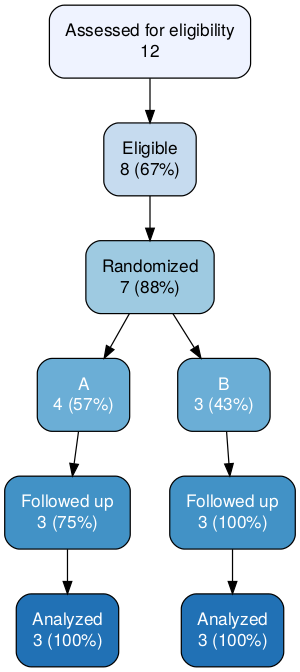

Note that this does not include all of the additional information for a full CONSORT diagram (exclusion reasons and counts, as well as numbers of patients who received their allocated interventions, who discontinued intervention, and who were excluded from analysis). It does, however, provide the main flow information.

Additional information can be obtained by viewing the nodes for patients in the pruned branches (but not their descendants). The `follow` parameter makes that easy:

```r
vtree(FakeRCT,"eligible randomized group followup analyzed",plain=TRUE,
  follow=list(eligible="Eligible",randomized="Randomized",followup="Followed up"),
  horiz=FALSE,showvarnames=FALSE,title="Assessed for eligibility")
```

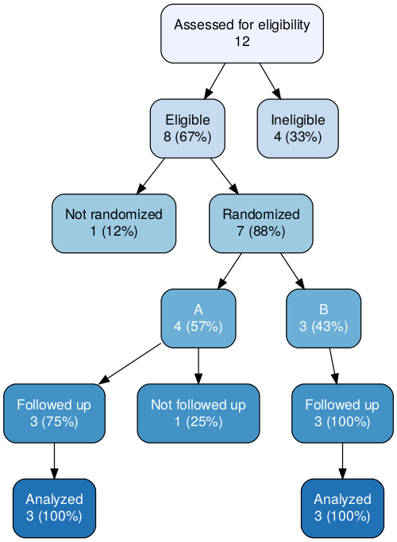

Finally, it may be useful to see the ID numbers in each node. This can be done using the `summary` parameter with the `%list%` code. Since IDs are less useful in the root note, the `%noroot%` code is also specified here:

```r
vtree(FakeRCT,"eligible randomized group followup analyzed",plain=TRUE,
  follow=list(eligible="Eligible",randomized="Randomized",followup="Followed up"),
  horiz=FALSE,showvarnames=FALSE,title="Assessed for eligibility",
  summary="id \nid: %list% %noroot%")
```

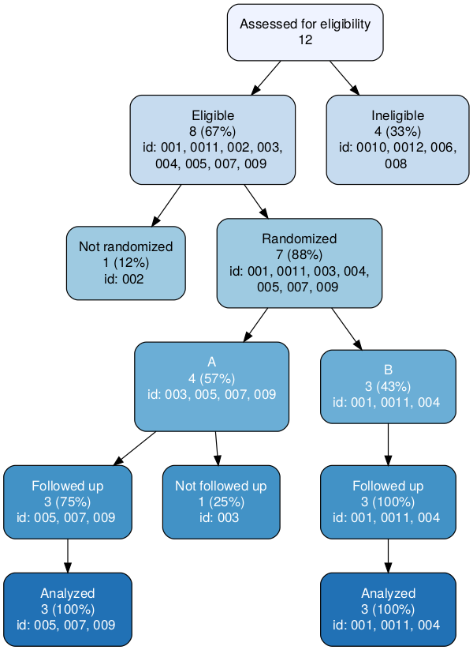

## Examples using R datasets

The `datasets` package is loaded in R by default. In the following section, `vtree` is applied to several of these data sets for illustrative purposes. Note that the variable trees generated by the commands below are not shown. The reader can try these commands to see what the variable trees look like, and experiment with many other possibilities.

### Esophageal cancer

The `esoph` data set (data from a case-control study of esophageal cancer in Ille-et-Vilaine, France), has 88 different combinations of age group, alcohol consumption, and tobacco consumption. Let’s examine the total number of cases and the total number of controls among patients aged 75 and older compared to the rest of the patients:

```r
# Relabel agegp 75+ to 75plus because vtree tries to parse the +
ESOPH <- esoph
levels(ESOPH$agegp)[levels(ESOPH$agegp)=="75+"] <- "75plus"

vtree(ESOPH,"agegp=75plus",sameline=TRUE,cdigits=0,
  summary=c("ncases \ncases=%sum%%leafonly%","ncontrols  controls=%sum%%leafonly%"))
```

### Hair and eye color

The `HairEyeColor` data set is an array representing a contingency table (also called a crosstab or crosstabulation). Before `vtree` can be applied to this data set, it is necessary to convert the table of crosstabulated frequencies to a data frame of cases. For convenience, the `vtree` package includes a helper function to do this, called `crosstabToCases`. It is adapted from a function listed on the [Cookbook for R website](http://www.cookbook-r.com/Manipulating_data/Converting_between_data_frames_and_contingency_tables/#countstocases-function)

```r
hec <- crosstabToCases(HairEyeColor)
```

There are a lot of combinations but let’s say we are especially interested in green eyes (as compared to non-green eyes). We can use the variable specification `Eye=Green` to do this:

```r
vtree(hec,"Hair Eye=Green Sex",sameline=TRUE)
```

### Titanic

The `Titanic` dataset is a 4-dimensional array of counts. First, let’s convert it to a dataframe of individuals:

```r
titanic <- crosstabToCases(Titanic)
```

We’ll specify `sameline=TRUE` so that the variable tree is a bit more compact:

```r
vtree(titanic,"Class Sex Age",summary="Survived=Yes \n%pct% survived",sameline=TRUE)
```

### mtcars

The `mtcars` data set was extracted from the 1974 Motor Trend US magazine, and comprises fuel consumption and 10 aspects of automobile design and performance for 32 automobiles (1973–74 models).

The rownames of the data set contain the names of the cars. Let’s move that information into a column. To do that, we’ll make a slightly altered version of the data frame which we’ll call `mt`:

```r
mt <- mtcars
mt$name <- rownames(mt)
rownames(mt) <- NULL
```

Now let’s look at the mean and standard deviation of horsepower (HP) by number of carburetors, nested within number of gears, and in turn nested within number of cylinders:

```r
vtree(mt,"cyl gear carb",summary="hp \nmean (SD) HP %mean% (%SD%)")
```

The above shows the mean and SD of horsepower by (1) number of cylinders; (2) number of gears (within number of cylinders); and (3) number of carburetors (within number of gears nested within number of cylinders). That’s a lot of information. Suppose instead that we are only interested in number 3 above, i.e. all combinations of number of cylinders, number of gears, and number of carburetors.

In that case, we can specify `ptable=TRUE`, To make the table a little easier to read, set the number of digits for the mean and SD to be zero, and relabel the variables.

```r
vtree(mt,"cyl gear carb",summary="hp mean (SD) HP %mean% (%SD%)",
  cdigits=0,labelvar=c(cyl="# cylinders",gear="# gears",carb="# carburetors"),
  ptable=TRUE)
```

We might also like to list the names of cars by number of carburetors nested within number of gears:

```r
vtree(mt,"gear carb",summary="name \n%list%%noroot%",splitwidth=50,sameline=TRUE,
  labelvar=c(gear="# gears",carb="# carburetors"))
```

### UCBAdmissions

The `UCBAdmissions` data is consists of aggregate data on applicants to graduate school at Berkeley for the six largest departments in 1973 classified by admission and sex. According to the data set Details, “This data set is frequently used for illustrating Simpson’s paradox, see Bickel et al. (1975). At issue is whether the data show evidence of sex bias in admission practices. There were 2691 male applicants, of whom 1198 (44.5%) were admitted, compared with 1835 female applicants of whom 557 (30.4%) were admitted.” Furthermore, “the apparent association between admission and sex stems from differences in the tendency of males and females to apply to the individual departments (females used to apply more to departments with higher rejection rates).”

First, we’ll convert the crosstab data to a data frame of cases, `ucb`:

```r
ucb <- crosstabToCases(UCBAdmissions)
```

Next, let’s look at admission rates by Gender, nested within department:

```r
vtree(ucb,"Dept Gender",summary="Admit=Admitted \n%pct% admitted",sameline=TRUE)
```

### ChickWeight

The `ChickWeight` data set is from an experiment on the effect of diet on early growth of chicks. Let’s look at the mean weight of chicks at birth (0 days of age) and 4 days of age, nested within type of diet. A simple variable tree can be produced like this:

```r
vtree(ChickWeight,"Diet Time",
  keep=list(Time=c("0","4")),summary="weight \nmean weight %mean%g")
```

To make the display a little easier to read, relabel the nodes and the `Time` variable:

```r
vtree(ChickWeight,"Diet Time",keep=list(Time=c("0","4")),
  labelnode=list(
    Diet=c("Diet 1"="1","Diet 2"="2","Diet 3"="3","Diet 4"="4"),
    Time=c("0 days"="0","4 days"="4")),
  labelvar=c(Time="Days since birth"),summary="weight \nmean weight %mean%g")
```

### InsectSprays

The `InsectSprays` data set contains counts of insects in agricultural experimental units treated with different insecticides. Let’s look at those counts by insecticide.

```r
vtree(InsectSprays,"spray",splitwidth=80,sameline=TRUE,
  summary="count \ncounts: %list%%noroot%",cdigits=0)
```

### ToothGrowth

The `ToothGrowth` data set contains the length of odontoblasts (cells responsible for tooth growth) in 60 guinea pigs. Each animal received one of three dose levels of vitamin C (0.5, 1, and 2 mg/day) by one of two delivery methods, orange juice or ascorbic acid (a form of vitamin C and coded as VC).

Let’s examine the percentage with length > 20 by dose nested within delivery method:

```r
vtree(ToothGrowth,"supp dose",summary="len>20 \n%pct% length > 20")
```

```r
vtree(ToothGrowth,"supp dose",summary="len>20 \n%pct% length > 20",
  labelvar=c("supp"="Supplement type","dose"="Dose (mg/day)"),
  labelnode=list(supp=c("Vitamin C"="VC","Orange Juice"="OJ")))
```